# Script for generating Fig.4f

This script visualizes the heatmap of protein activities for top 4 cancer cohorts (COAD/READ, STAD/ESCA/, GBM/LGG, PAAD)

**Note**: Protein activity data (derived from gene expression signatures normalized within each tissue type) and TCGA-MOMA clusting information are required to run this code.

Please (1) download *supplementary_data_inputs-for-fig4f.tar.gz* from *Files/Data/Transcriptional Data Analysis Subgroup Files/supplementary_data_oncomatch* on the HCMI synapse page, and(2) unzip it in the same directory as this script.

#### Load libraries

Please install libraries if they are not pre-installed in your system.

```r
library(openxlsx)
```

```r
library(PISCES)
library(plyr)
library(ggplot2)
library(pheatmap)
library(ComplexHeatmap)
```

[output not shown]

```r
library(matrixStats)
library(pals)
```

### Load data

Load TCGA protein activity for top 4 cancer cohorts:

```r
fl.tcga =list.files("./supplementary_data_inputs-for-fig4f", full.names = T)
fl.tcga = fl.tcga[grepl("pmat-TCGA",fl.tcga)&grepl(".rds", fl.tcga)]
head(fl.tcga)
```

```
## [1] "./supplementary_data_inputs-for-fig4f/pmat-TCGA-COAD_centerByTissue_regulCOAD_aracne3-mi00-size100_narnea.rds"
## [2] "./supplementary_data_inputs-for-fig4f/pmat-TCGA-EAC_centerByTissue_regulEAC_aracne3-mi00-size100_narnea.rds"
## [3] "./supplementary_data_inputs-for-fig4f/pmat-TCGA-GBM_centerByTissue_regulGBM_aracne3-mi00-size100_narnea.rds"
## [4] "./supplementary_data_inputs-for-fig4f/pmat-TCGA-PAAD_centerByTissue_regulPAAD_aracne3-mi00-size100_narnea.rds"
## [5] "./supplementary_data_inputs-for-fig4f/pmat-TCGA-STAD_centerByTissue_regulSTAD_aracne3-mi00-size100_narnea.rds"
```

```r
pmat.tcga= lapply(fl.tcga, function(fname) readRDS(fname))
names(pmat.tcga) = gsub(".*pmat-TCGA-|_centerByTissue_.*","",fl.tcga)
sapply(pmat.tcga, dim)
```

```
##      COAD  EAC  GBM PAAD STAD
## [1,] 3197 3197 3197 3197 3197
## [2,]  521   79  174  183  407
```

Get a table of sample information from the TCGA protein activity data:

```r
tcga.tb = data.frame(sample=unlist(lapply(pmat.tcga,colnames)),
                     group= rep(names(pmat.tcga), sapply(pmat.tcga,ncol)))

tcga.tb$moma.key= gsub("[A-Z]$","",tcga.tb$sample)
head(tcga.tb)
```

|  | sample | group | moma.key |
| --- | --- | --- | --- |
| COAD1 | TCGA-A6-5664-01A | COAD | TCGA-A6-5664-01 |
| COAD2 | TCGA-D5-6530-01A | COAD | TCGA-D5-6530-01 |
| COAD3 | TCGA-AA-3556-01A | COAD | TCGA-AA-3556-01 |
| COAD4 | TCGA-AA-3660-11A | COAD | TCGA-AA-3660-11 |
| COAD5 | TCGA-AA-3818-01A | COAD | TCGA-AA-3818-01 |
| COAD6 | TCGA-AA-3660-01A | COAD | TCGA-AA-3660-01 |

Concatenate a list of the protein activity matrices to a single matrix:

```r
gc.tcga = Reduce("intersect", lapply(pmat.tcga, rownames)) # common TFs across 4 matrices
pmat.tcga= do.call(cbind, lapply(pmat.tcga, function(x) x[gc.tcga,]))
```

Load MOMA subtype info.: *The information of TCGA-MOMA subtypes was obtained from Paull et al. 2021 (doi: 10.1016/j.cell.2020.11.045).

```r
load("./supplementary_data_inputs-for-fig4f/pancancer.clusters.byTissue.final.rda")
```

Combininb MOMA information to the table of TCGA sample information:

```r
moma.tb = data.frame(sample=unlist(lapply(pancancer.tissue.clusters,names)),
                     group = paste(rep(toupper(names(pancancer.tissue.clusters)),sapply(pancancer.tissue.clusters,length)), unlist(pancancer.tissue.clusters), sep="_"))

tcga.tb$moma_type = moma.tb$group[match(tcga.tb$moma.key, moma.tb$sample)]
head(tcga.tb)
```

|  | sample | group | moma.key | moma_type |
| --- | --- | --- | --- | --- |
| COAD1 | TCGA-A6-5664-01A | COAD | TCGA-A6-5664-01 | COAD_7 |
| COAD2 | TCGA-D5-6530-01A | COAD | TCGA-D5-6530-01 | COAD_7 |
| COAD3 | TCGA-AA-3556-01A | COAD | TCGA-AA-3556-01 | COAD_3 |
| COAD4 | TCGA-AA-3660-11A | COAD | TCGA-AA-3660-11 | NA |
| COAD5 | TCGA-AA-3818-01A | COAD | TCGA-AA-3818-01 | COAD_4 |
| COAD6 | TCGA-AA-3660-01A | COAD | TCGA-AA-3660-01 | COAD_5 |

Load meta information for the HCMI protein activity:

```r
meta.hcmi = read.delim("./supplementary_data_inputs-for-fig4f/metaTable-HCMI-top4tissues.tsv")
```

Load HCMI protein activity (derived from gene expression signatures normalized within each tissue type) for top 4 cancer cohorts: * The data were from *OncoMatchAnalysis_tumorHCMI-vs-modelHCMI*.

```r
fl.hcmi =list.files("./supplementary_data_inputs-for-fig4f/", full.names = T)
fl.hcmi = fl.hcmi[grepl("protAct-HCMI",fl.hcmi)&grepl(".rds", fl.hcmi)]

x.set = data.frame(cancer_type=c("Colorectal Cancer", "Esophageal Cancer", "Stomach Cancer", "Glioblastoma", "Pancreatic Cancer"),
                   network=c("COAD","STAD","STAD","GBM","PAAD"))

pmat.hcmi = lapply(1:nrow(x.set), function(k){
  print(k)
  fname= fl.hcmi[grepl(x.set$cancer_type[k], fl.hcmi) & grepl(x.set$network[k], fl.hcmi)]
  print(fname)
  ind.k = meta.hcmi$file_aliquot_id3[which(meta.hcmi$cancer_type==x.set$cancer_type[k])]
  r=readRDS(fname)[,ind.k]
  return(r)
})
```

```
## [1] 1
## [1] "./supplementary_data_inputs-for-fig4f//protAct-HCMI-Colorectal Cancer_normalized-within-cohort_network-COAD.rds"
## [1] 2
## [1] "./supplementary_data_inputs-for-fig4f//protAct-HCMI-Esophageal Cancer_normalized-within-cohort_network-STAD.rds"
## [1] 3
## [1] "./supplementary_data_inputs-for-fig4f//protAct-HCMI-Stomach Cancer_normalized-within-cohort_network-STAD.rds"
## [1] 4
## [1] "./supplementary_data_inputs-for-fig4f//protAct-HCMI-Glioblastoma_normalized-within-cohort_network-GBM.rds"
## [1] 5
## [1] "./supplementary_data_inputs-for-fig4f//protAct-HCMI-Pancreatic Cancer_normalized-within-cohort_network-PAAD.rds"
```

```r
names(pmat.hcmi) =  x.set$cancer_type
sapply(pmat.hcmi, dim)
```

```
##      Colorectal Cancer Esophageal Cancer Stomach Cancer Glioblastoma
## [1,]              3197              3197           3197         3197
## [2,]               243                94             47          102
##      Pancreatic Cancer
## [1,]              3197
## [2,]               148
```

```r
tfc= Reduce("intersect",lapply(pmat.hcmi, rownames)) ## common TFs across matrices
pmat.hcmi = do.call(cbind, lapply(pmat.hcmi, function(x) x[tfc,]))
dim(pmat.hcmi)
```

```
## [1] 3197  634
```

Final HCMI-metadata corresponding to the protein activity profiles:

```r
hcmi.tb = meta.hcmi[match(colnames(pmat.hcmi), meta.hcmi$file_aliquot_id3),
                    c("file_aliquot_id3","cancer_type","sample_type","category","preservation_method","cmdc_model_media","moma_type")]
colnames(hcmi.tb)=c("sample","cancer_type","sample_type","category","preservation","media","moma_type")
```

#### Preparing inputs for heatmap

Combine HCMI and TCGA protein activity data:

```r
gc.comm = intersect(rownames(pmat.hcmi), rownames(pmat.tcga)) # Common TFs between two datasets

pmat.comb = cbind(pmat.hcmi[gc.comm,], pmat.tcga[gc.comm,]) # combined protein activity


meta.comb = rbind(data.frame(hcmi.tb, tcga_group=NA,set="HCMI"),
                  data.frame(sample=tcga.tb$sample, cancer_type=NA, sample_type="Tumor", category=NA, preservation=NA, media=NA, moma_type=tcga.tb$moma_type,
                             tcga_group=tcga.tb$group, set="TCGA")) # combine meta data
```

Remove duplicated samples

```r
ind.dup = which(duplicated(meta.comb$sample))
pmat.comb = pmat.comb[,-ind.dup]
meta.comb = meta.comb[-ind.dup,]
```

Select for top 4 corhots

```r
ind.sel = which(grepl("Colorectal|Glioblastoma|Stomach|Esophageal|Pancreatic",meta.comb$cancer_type) | grepl("COAD|READ|GBM|LGG|PAAD|STAD", meta.comb$tcga_group))
pmat.comb = pmat.comb[,ind.sel]
meta.comb = meta.comb[ind.sel,]
```

Refine meta information:

```r
meta.comb$cancer_type[grep("COAD|READ", meta.comb$tcga_group)]="Colorectal Cancer"
meta.comb$cancer_type[grep("GBM|LGG", meta.comb$tcga_group)]="Glioblastoma"
meta.comb$cancer_type[grep("PAAD", meta.comb$tcga_group)]="Pancreatic Cancer"
meta.comb$cancer_type[grep("STAD", meta.comb$tcga_group)]="Stomach Cancer"

meta.comb$cancer_type[grep("Stomach|Esophageal", meta.comb$cancer_type)]="Gastroesophageal cancer"

meta.comb$tcga_group[meta.comb$set=="HCMI"]="HCMI"
sum(is.na(meta.comb$tcga_group))
```

```
## [1] 0
```

Remove redundant TCGA cohorts (LGG, READ)

```r
ind.sel = which(!grepl("LGG|READ",meta.comb$tcga_group) & !is.na(meta.comb$moma_type))
pmat.comb = pmat.comb[,ind.sel]
meta.comb = meta.comb[ind.sel,]
```

#### Get MOMA signatures:

```r
# Generate MOMA signatures using Stouffer integration method:
moma.var = ddply(cbind(meta.comb[,c("cancer_type","tcga_group","moma_type")],
                       t(pmat.comb)),
                 .(cancer_type, tcga_group, moma_type), function(x) colSums(x[,-c(1:3)])/sqrt(nrow(x)))

moma.var = moma.var[!is.na(moma.var$tcga_group) & !is.na(moma.var$moma_type),]
moma.var = moma.var[moma.var$tcga_group!="HCMI",] # Moma signatures limited to TCGA samples
moma.var = moma.var[order(moma.var$cancer_type, moma.var$moma_type),] # sort moma signatures first by cancer type then moma type

# Get top 50 MRs in each MOMA signature
moma.sig=apply(moma.var[,-c(1:3)], 1, function(x) rownames(pmat.comb)[order(x,decreasing = T)[1:50]])

sig_final = lapply(unique(moma.var$cancer_type), function(k) (as.vector(moma.sig[,moma.var$cancer_type==k])))
sig.group = rep(moma.var$moma_type, each=50)
table(sig.group)
```

```
## sig.group
## COAD_1 COAD_2 COAD_3 COAD_4 COAD_5 COAD_6 COAD_7 COAD_8  GBM_1  GBM_2  GBM_3
##     50     50     50     50     50     50     50     50     50     50     50
##  GBM_4  GBM_5 PAAD_1 PAAD_2 PAAD_3 PAAD_4 PAAD_5 PAAD_6 PAAD_7 STAD_1 STAD_2
##     50     50     50     50     50     50     50     50     50     50     50
## STAD_3
##     50
```

```r
sig_final = unlist(sig_final) # Final MOMA signatures: unlisted top 50 MRs for COAD_1, COAD_2, ..., PADD_1, PAAD_2,..

# protein activity limited for MOMA signatures
mat = pmat.comb[sig_final,]

# Add annotation (cancer type + moma subtype) to the meta table
meta.comb$cancer_type2 = paste(meta.comb$cancer_type, "_", meta.comb$moma_type,  sep="")
```

Column pre-sorting:

```r
dend.top = cluster_within_group(mat, factor(meta.comb$cancer_type2[1:ncol(mat)]))
oi.dend.top = order.dendrogram(dend.top)

#Moma cross-subtype clustering:
names(oi.dend.top) = meta.comb$cancer_type[oi.dend.top]
oi.dend.top = oi.dend.top[order(names(oi.dend.top))]

mat=mat[,oi.dend.top]
meta.comb = meta.comb[oi.dend.top,]
unique(meta.comb$moma_type)
```

```
##  [1] "COAD_1" "COAD_8" "COAD_7" "COAD_6" "COAD_5" "COAD_4" "COAD_2" "COAD_3"
##  [9] "STAD_3" "STAD_2" "STAD_1" "GBM_3"  "GBM_4"  "GBM_1"  "GBM_2"  "GBM_5"
## [17] "PAAD_6" "PAAD_3" "PAAD_4" "PAAD_5" "PAAD_7" "PAAD_2" "PAAD_1"
```

Row pre-sorting:

```r
sig.group = factor(sig.group, levels=unique(sig.group))
dend.row = cluster_within_group(t(mat), sig.group)
oi.dend.row = order.dendrogram(dend.row)
names(oi.dend.row) = sig.group[oi.dend.row]

### moma cross-subtype clustering:
oi.dend.row= oi.dend.row[order(factor(names(oi.dend.row), levels=unique(meta.comb$moma_type)))]
unique(names(oi.dend.row))
```

```
##  [1] "COAD_1" "COAD_8" "COAD_7" "COAD_6" "COAD_5" "COAD_4" "COAD_2" "COAD_3"
##  [9] "STAD_3" "STAD_2" "STAD_1" "GBM_3"  "GBM_4"  "GBM_1"  "GBM_2"  "GBM_5"
## [17] "PAAD_6" "PAAD_3" "PAAD_4" "PAAD_5" "PAAD_7" "PAAD_2" "PAAD_1"
```

```r
mat=mat[oi.dend.row,]
```

Column annotation:

```r
anno_col = meta.comb[,c("cancer_type","sample_type","preservation",
                        "media","tcga_group","moma_type")]
rownames(anno_col) = meta.comb$sample


meta.comb$moma_type= gsub("[A-Z]+_","",meta.comb$moma_type)

color.moma = trubetskoy(8)
names(color.moma)=1:8

## dataset group
group_set = meta.comb$tcga_group
group_set[group_set!="HCMI"]="TCGA"
color.group_set = c("grey80", "black")
names(color.group_set) = c("TCGA","HCMI")

## sample types
color.sample_type = c("white","blue","red")
names(color.sample_type)=c("Tumor","3D_model","2D_model")

column_ha = HeatmapAnnotation(set=group_set,
                              # cancer_type=meta.comb$cancer_type,
                              sample_type=meta.comb$sample_type,
                              moma_type = meta.comb$moma_type,
                              col=list(moma_type=color.moma,
                                       # cancer_type=color.cancer_type,
                                       sample_type=color.sample_type,
                                       set=color.group_set))
```

Row annotation:

```r
row_ha = rowAnnotation(signature=gsub(".+_","",names(oi.dend.row)),
                       col=list(signature=color.moma))
```

Heatmap:

```r
moma.pred = gsub("Colorectal Cancer_|Gastroesophageal cancer_|Glioblastoma_|Pancreatic Cancer_","",meta.comb$cancer_type2)
moma.pred = factor(moma.pred, levels=c(paste("COAD_",1:8, sep=""),
                                       paste("STAD_",1:3, sep=""),
                                       paste("GBM_",1:5, sep=""),
                                       paste("PAAD_",1:7, sep="")))

sig.group2 = factor(names(oi.dend.row),
                    levels=c(paste("COAD_",1:8, sep=""),
                             paste("STAD_",1:3, sep=""),
                             paste("GBM_",1:5, sep=""),
                             paste("PAAD_",1:7, sep="")))

library(circlize)
```

```r
col_fun = colorRamp2(c(-20, 0, 10,20), c("#232AF7", "white", "#F93C58","#A80303"))


hmap = Heatmap(mat=as.matrix(mat),
               cluster_columns=FALSE,
               column_split = moma.pred,

               cluster_rows=FALSE,
               row_split = sig.group2,

               show_row_names=FALSE,
               show_column_names = FALSE,
               use_raster = FALSE,

               top_annotation = column_ha[1:ncol(mat)],
               left_annotation = row_ha,
               row_gap = unit(0, "mm"),
               column_gap = unit(0, "mm"),
               border = TRUE,
               name = "Protein Activity")
```

[output not shown]

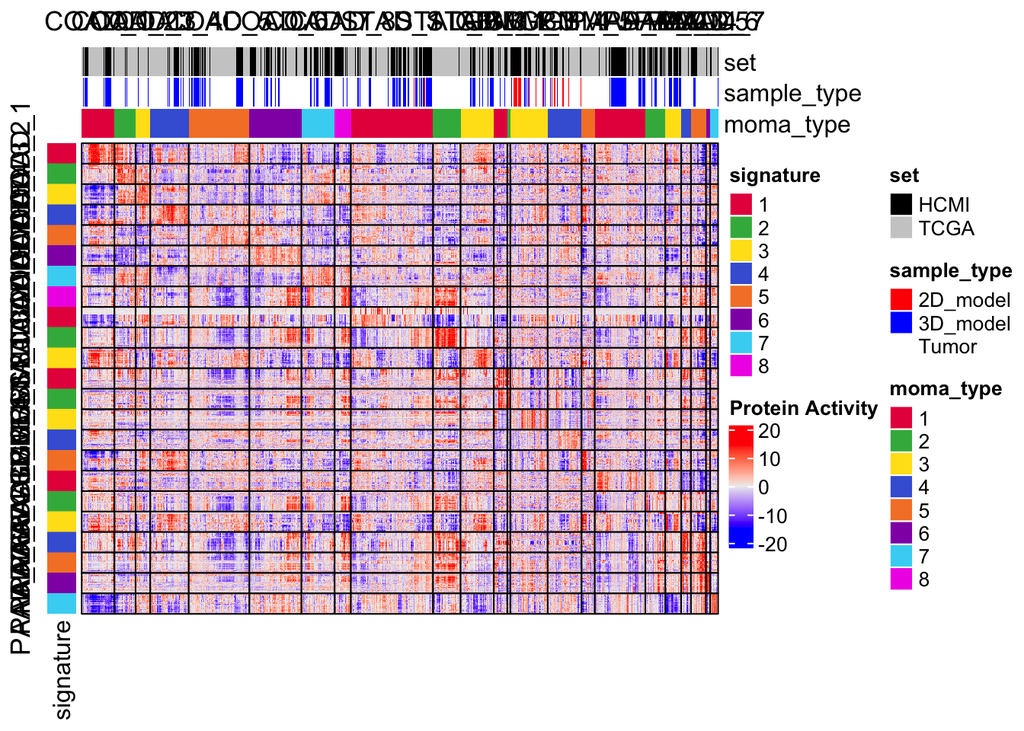

```r
hmap
```